# EDA

## PART 1: EDA

В этом ноутбуке проведем основной анализ данных соревнования. Я буду работать только с основными таблицами из соревнования: **application_{train|test}.csv**. В них много признаков и есть чем заняться. Посмотрим, какой результат в итоге получится в рейтинге, используя только эти данные из соревнования.

```python
import numpy as np
import pandas as pd
import pickle

from eda_module import *

import seaborn as sns
import plotly.plotly as py
import cufflinks as cf
sns.set_style('whitegrid')
from matplotlib import pyplot as plt
%matplotlib inline

import warnings
warnings.filterwarnings('ignore')

pd.set_option('display.max_rows', 500)
pd.set_option('display.max_columns', 500)
pd.set_option('display.max_info_columns', 250)
```

```python
df_application_train = pd.read_csv('data/application_train.csv')
df_application_test = pd.read_csv('data/application_test.csv')

print('application train:', df_application_train.shape)
print('application test:', df_application_test.shape)
```

```
application train: (307511, 122)
application test: (48744, 121)
```

```python
df_application_train.head()
```

|  | SK_ID_CURR | TARGET | NAME_CONTRACT_TYPE | CODE_GENDER | FLAG_OWN_CAR | FLAG_OWN_REALTY | CNT_CHILDREN | AMT_INCOME_TOTAL | AMT_CREDIT | AMT_ANNUITY | AMT_GOODS_PRICE | NAME_TYPE_SUITE | NAME_INCOME_TYPE | NAME_EDUCATION_TYPE | NAME_FAMILY_STATUS | NAME_HOUSING_TYPE | REGION_POPULATION_RELATIVE | DAYS_BIRTH | DAYS_EMPLOYED | DAYS_REGISTRATION | DAYS_ID_PUBLISH | OWN_CAR_AGE | FLAG_MOBIL | FLAG_EMP_PHONE | FLAG_WORK_PHONE | FLAG_CONT_MOBILE | FLAG_PHONE | FLAG_EMAIL | OCCUPATION_TYPE | … |
| --- | --- | --- | --- | --- | --- | --- | --- | --- | --- | --- | --- | --- | --- | --- | --- | --- | --- | --- | --- | --- | --- | --- | --- | --- | --- | --- | --- | --- | --- | --- |
| 0 | 100002 | 1 | Cash loans | M | N | Y | 0 | 202500.0 | 406597.5 | 24700.5 | 351000.0 | Unaccompanied | Working | Secondary / secondary special | Single / not married | House / apartment | 0.018801 | -9461 | -637 | -3648.0 | -2120 | NaN | 1 | 1 | 0 | 1 | 1 | 0 | Laborers | … |
| 1 | 100003 | 0 | Cash loans | F | N | N | 0 | 270000.0 | 1293502.5 | 35698.5 | 1129500.0 | Family | State servant | Higher education | Married | House / apartment | 0.003541 | -16765 | -1188 | -1186.0 | -291 | NaN | 1 | 1 | 0 | 1 | 1 | 0 | Core staff | … |
| 2 | 100004 | 0 | Revolving loans | M | Y | Y | 0 | 67500.0 | 135000.0 | 6750.0 | 135000.0 | Unaccompanied | Working | Secondary / secondary special | Single / not married | House / apartment | 0.010032 | -19046 | -225 | -4260.0 | -2531 | 26.0 | 1 | 1 | 1 | 1 | 1 | 0 | Laborers | … |
| 3 | 100006 | 0 | Cash loans | F | N | Y | 0 | 135000.0 | 312682.5 | 29686.5 | 297000.0 | Unaccompanied | Working | Secondary / secondary special | Civil marriage | House / apartment | 0.008019 | -19005 | -3039 | -9833.0 | -2437 | NaN | 1 | 1 | 0 | 1 | 0 | 0 | Laborers | … |
| 4 | 100007 | 0 | Cash loans | M | N | Y | 0 | 121500.0 | 513000.0 | 21865.5 | 513000.0 | Unaccompanied | Working | Secondary / secondary special | Single / not married | House / apartment | 0.028663 | -19932 | -3038 | -4311.0 | -3458 | NaN | 1 | 1 | 0 | 1 | 0 | 0 | Core staff | … |

### Распределение целевой переменной

Сразу можно посмотреть на распределение таргета, чтобы иметь представление, на сколько сильный дисбаланс классов и есть он вообще.

```python
df_application_train['TARGET'].value_counts(normalize=True)*100
```

```
0    91.927118
1     8.072882
Name: TARGET, dtype: float64
```

Около 8% данных описывают должников. Очень мало, но ожидаемо. Как минимум, в дальнейшем стоит позаботиться о корректной кросс-валидации.

### Пропущенные значения

Оценим, как много пропущенных значений в тренировочном и тестовом наборах данных.

Видим, что около половины признаков имеют пропуски. В группах признаков **AVG**, **MODE**, **MEDI** процент пропущенных значений иногда достигает 70%. Возможно стоит попробовать их вообще удалить из модели.

```python
missing_table = missing_values_train_test(df_application_train, df_application_test, 'TARGET')
columns_with_missing = missing_table.index.values
print(missing_table.shape)
missing_table
```

```
(67, 4)
```

|  | TRAIN, amount | TRAIN, % | TEST, amount | TEST, % |
| --- | --- | --- | --- | --- |
| AMT_ANNUITY | 12 | 0.003902 | 24 | 0.049237 |
| AMT_GOODS_PRICE | 278 | 0.090403 | 0 | 0.000000 |
| NAME_TYPE_SUITE | 1292 | 0.420148 | 911 | 1.868948 |
| OWN_CAR_AGE | 202929 | 65.990810 | 32312 | 66.289184 |
| OCCUPATION_TYPE | 96391 | 31.345545 | 15605 | 32.014197 |
| CNT_FAM_MEMBERS | 2 | 0.000650 | 0 | 0.000000 |
| EXT_SOURCE_1 | 173378 | 56.381073 | 20532 | 42.122107 |
| EXT_SOURCE_2 | 660 | 0.214626 | 8 | 0.016412 |
| EXT_SOURCE_3 | 60965 | 19.825307 | 8668 | 17.782701 |
| APARTMENTS_AVG | 156061 | 50.749729 | 23887 | 49.005006 |
| BASEMENTAREA_AVG | 179943 | 58.515956 | 27641 | 56.706466 |
| YEARS_BEGINEXPLUATATION_AVG | 150007 | 48.781019 | 22856 | 46.889874 |
| YEARS_BUILD_AVG | 204488 | 66.497784 | 31818 | 65.275726 |
| COMMONAREA_AVG | 214865 | 69.872297 | 33495 | 68.716150 |
| ELEVATORS_AVG | 163891 | 53.295980 | 25189 | 51.676104 |
| ENTRANCES_AVG | 154828 | 50.348768 | 23579 | 48.373133 |
| FLOORSMAX_AVG | 153020 | 49.760822 | 23321 | 47.843837 |
| FLOORSMIN_AVG | 208642 | 67.848630 | 32466 | 66.605121 |
| LANDAREA_AVG | 182590 | 59.376738 | 28254 | 57.964057 |
| LIVINGAPARTMENTS_AVG | 210199 | 68.354953 | 32780 | 67.249302 |
| LIVINGAREA_AVG | 154350 | 50.193326 | 23552 | 48.317742 |
| NONLIVINGAPARTMENTS_AVG | 213514 | 69.432963 | 33347 | 68.412523 |
| NONLIVINGAREA_AVG | 169682 | 55.179164 | 26084 | 53.512227 |
| APARTMENTS_MODE | 156061 | 50.749729 | 23887 | 49.005006 |
| BASEMENTAREA_MODE | 179943 | 58.515956 | 27641 | 56.706466 |
| YEARS_BEGINEXPLUATATION_MODE | 150007 | 48.781019 | 22856 | 46.889874 |
| YEARS_BUILD_MODE | 204488 | 66.497784 | 31818 | 65.275726 |
| COMMONAREA_MODE | 214865 | 69.872297 | 33495 | 68.716150 |
| ELEVATORS_MODE | 163891 | 53.295980 | 25189 | 51.676104 |
| ENTRANCES_MODE | 154828 | 50.348768 | 23579 | 48.373133 |
| FLOORSMAX_MODE | 153020 | 49.760822 | 23321 | 47.843837 |
| FLOORSMIN_MODE | 208642 | 67.848630 | 32466 | 66.605121 |
| LANDAREA_MODE | 182590 | 59.376738 | 28254 | 57.964057 |
| LIVINGAPARTMENTS_MODE | 210199 | 68.354953 | 32780 | 67.249302 |
| LIVINGAREA_MODE | 154350 | 50.193326 | 23552 | 48.317742 |
| NONLIVINGAPARTMENTS_MODE | 213514 | 69.432963 | 33347 | 68.412523 |
| NONLIVINGAREA_MODE | 169682 | 55.179164 | 26084 | 53.512227 |
| APARTMENTS_MEDI | 156061 | 50.749729 | 23887 | 49.005006 |
| BASEMENTAREA_MEDI | 179943 | 58.515956 | 27641 | 56.706466 |
| YEARS_BEGINEXPLUATATION_MEDI | 150007 | 48.781019 | 22856 | 46.889874 |
| YEARS_BUILD_MEDI | 204488 | 66.497784 | 31818 | 65.275726 |
| COMMONAREA_MEDI | 214865 | 69.872297 | 33495 | 68.716150 |
| ELEVATORS_MEDI | 163891 | 53.295980 | 25189 | 51.676104 |
| ENTRANCES_MEDI | 154828 | 50.348768 | 23579 | 48.373133 |
| FLOORSMAX_MEDI | 153020 | 49.760822 | 23321 | 47.843837 |
| FLOORSMIN_MEDI | 208642 | 67.848630 | 32466 | 66.605121 |
| LANDAREA_MEDI | 182590 | 59.376738 | 28254 | 57.964057 |
| LIVINGAPARTMENTS_MEDI | 210199 | 68.354953 | 32780 | 67.249302 |
| LIVINGAREA_MEDI | 154350 | 50.193326 | 23552 | 48.317742 |
| NONLIVINGAPARTMENTS_MEDI | 213514 | 69.432963 | 33347 | 68.412523 |
| NONLIVINGAREA_MEDI | 169682 | 55.179164 | 26084 | 53.512227 |
| FONDKAPREMONT_MODE | 210295 | 68.386172 | 32797 | 67.284179 |
| HOUSETYPE_MODE | 154297 | 50.176091 | 23619 | 48.455194 |
| TOTALAREA_MODE | 148431 | 48.268517 | 22624 | 46.413918 |
| WALLSMATERIAL_MODE | 156341 | 50.840783 | 23893 | 49.017315 |
| EMERGENCYSTATE_MODE | 145755 | 47.398304 | 22209 | 45.562531 |
| OBS_30_CNT_SOCIAL_CIRCLE | 1021 | 0.332021 | 29 | 0.059495 |
| DEF_30_CNT_SOCIAL_CIRCLE | 1021 | 0.332021 | 29 | 0.059495 |
| OBS_60_CNT_SOCIAL_CIRCLE | 1021 | 0.332021 | 29 | 0.059495 |
| DEF_60_CNT_SOCIAL_CIRCLE | 1021 | 0.332021 | 29 | 0.059495 |
| DAYS_LAST_PHONE_CHANGE | 1 | 0.000325 | 0 | 0.000000 |
| AMT_REQ_CREDIT_BUREAU_HOUR | 41519 | 13.501631 | 6049 | 12.409732 |
| AMT_REQ_CREDIT_BUREAU_DAY | 41519 | 13.501631 | 6049 | 12.409732 |
| AMT_REQ_CREDIT_BUREAU_WEEK | 41519 | 13.501631 | 6049 | 12.409732 |
| AMT_REQ_CREDIT_BUREAU_MON | 41519 | 13.501631 | 6049 | 12.409732 |
| AMT_REQ_CREDIT_BUREAU_QRT | 41519 | 13.501631 | 6049 | 12.409732 |
| AMT_REQ_CREDIT_BUREAU_YEAR | 41519 | 13.501631 | 6049 | 12.409732 |

### Типы данных

```python
df_application_train.dtypes.value_counts()
```

```
float64    65
int64      41
object     16
dtype: int64
```

```python
df_application_test.dtypes.value_counts()
```

```
float64    65
int64      40
object     16
dtype: int64
```

```python
df_application_train.info()
```

```
<class 'pandas.core.frame.DataFrame'>
RangeIndex: 307511 entries, 0 to 307510
Data columns (total 122 columns):
SK_ID_CURR                      307511 non-null int64
TARGET                          307511 non-null int64
NAME_CONTRACT_TYPE              307511 non-null object
CODE_GENDER                     307511 non-null object
FLAG_OWN_CAR                    307511 non-null object
FLAG_OWN_REALTY                 307511 non-null object
CNT_CHILDREN                    307511 non-null int64
AMT_INCOME_TOTAL                307511 non-null float64
AMT_CREDIT                      307511 non-null float64
AMT_ANNUITY                     307499 non-null float64
AMT_GOODS_PRICE                 307233 non-null float64
NAME_TYPE_SUITE                 306219 non-null object
NAME_INCOME_TYPE                307511 non-null object
NAME_EDUCATION_TYPE             307511 non-null object
NAME_FAMILY_STATUS              307511 non-null object
NAME_HOUSING_TYPE               307511 non-null object
REGION_POPULATION_RELATIVE      307511 non-null float64
DAYS_BIRTH                      307511 non-null int64
DAYS_EMPLOYED                   307511 non-null int64
DAYS_REGISTRATION               307511 non-null float64
DAYS_ID_PUBLISH                 307511 non-null int64
OWN_CAR_AGE                     104582 non-null float64
FLAG_MOBIL                      307511 non-null int64
FLAG_EMP_PHONE                  307511 non-null int64
FLAG_WORK_PHONE                 307511 non-null int64
FLAG_CONT_MOBILE                307511 non-null int64
FLAG_PHONE                      307511 non-null int64
FLAG_EMAIL                      307511 non-null int64
OCCUPATION_TYPE                 211120 non-null object
CNT_FAM_MEMBERS                 307509 non-null float64
REGION_RATING_CLIENT            307511 non-null int64
REGION_RATING_CLIENT_W_CITY     307511 non-null int64
WEEKDAY_APPR_PROCESS_START      307511 non-null object
HOUR_APPR_PROCESS_START         307511 non-null int64
REG_REGION_NOT_LIVE_REGION      307511 non-null int64
REG_REGION_NOT_WORK_REGION      307511 non-null int64
LIVE_REGION_NOT_WORK_REGION     307511 non-null int64
```

[output cut: 72 more lines]

```
FLAG_DOCUMENT_15                307511 non-null int64
FLAG_DOCUMENT_16                307511 non-null int64
FLAG_DOCUMENT_17                307511 non-null int64
FLAG_DOCUMENT_18                307511 non-null int64
FLAG_DOCUMENT_19                307511 non-null int64
FLAG_DOCUMENT_20                307511 non-null int64
FLAG_DOCUMENT_21                307511 non-null int64
AMT_REQ_CREDIT_BUREAU_HOUR      265992 non-null float64
AMT_REQ_CREDIT_BUREAU_DAY       265992 non-null float64
AMT_REQ_CREDIT_BUREAU_WEEK      265992 non-null float64
AMT_REQ_CREDIT_BUREAU_MON       265992 non-null float64
AMT_REQ_CREDIT_BUREAU_QRT       265992 non-null float64
AMT_REQ_CREDIT_BUREAU_YEAR      265992 non-null float64
dtypes: float64(65), int64(41), object(16)
memory usage: 286.2+ MB
```

### Количество уникальных значений

Стоит сразу понять, различаются ли уникальные значения в тренировочном и тестовом наборах для категориальных признаков. Это будет важно при one hot encoding.

```python
nunique_table = get_nunique_values_train_test(df_application_train, df_application_test)
nunique_table
```

|  | feature | count, TRAIN | count, TEST |
| --- | --- | --- | --- |
| 0 | SK_ID_CURR | 307511 | 48744.0 |
| 1 | TARGET | 2 | NaN |
| 2 | NAME_CONTRACT_TYPE | 2 | 2.0 |
| 3 | CODE_GENDER | 3 | 2.0 |
| 4 | FLAG_OWN_CAR | 2 | 2.0 |
| 5 | FLAG_OWN_REALTY | 2 | 2.0 |
| 6 | CNT_CHILDREN | 15 | 11.0 |
| 7 | AMT_INCOME_TOTAL | 2548 | 606.0 |
| 8 | AMT_CREDIT | 5603 | 2937.0 |
| 9 | AMT_ANNUITY | 13672 | 7491.0 |
| 10 | AMT_GOODS_PRICE | 1002 | 677.0 |
| 11 | NAME_TYPE_SUITE | 7 | 7.0 |
| 12 | NAME_INCOME_TYPE | 8 | 7.0 |
| 13 | NAME_EDUCATION_TYPE | 5 | 5.0 |
| 14 | NAME_FAMILY_STATUS | 6 | 5.0 |
| 15 | NAME_HOUSING_TYPE | 6 | 6.0 |
| 16 | REGION_POPULATION_RELATIVE | 81 | 81.0 |
| 17 | DAYS_BIRTH | 17460 | 15477.0 |
| 18 | DAYS_EMPLOYED | 12574 | 7863.0 |
| 19 | DAYS_REGISTRATION | 15688 | 12618.0 |
| 20 | DAYS_ID_PUBLISH | 6168 | 5880.0 |
| 21 | OWN_CAR_AGE | 62 | 52.0 |
| 22 | FLAG_MOBIL | 2 | 2.0 |
| 23 | FLAG_EMP_PHONE | 2 | 2.0 |
| 24 | FLAG_WORK_PHONE | 2 | 2.0 |
| 25 | FLAG_CONT_MOBILE | 2 | 2.0 |
| 26 | FLAG_PHONE | 2 | 2.0 |
| 27 | FLAG_EMAIL | 2 | 2.0 |
| 28 | OCCUPATION_TYPE | 18 | 18.0 |
| 29 | CNT_FAM_MEMBERS | 17 | 12.0 |

[output cut: 92 more lines]

Ниже я разбила все признаки по группам. Для удобства эти группы сохраняются в словарь, который можно будет использовать на следующих этапах.

```python
column_id = 'SK_ID_CURR'
column_target = 'TARGET'

columns_float = ['AMT_INCOME_TOTAL', 'AMT_CREDIT', 'AMT_ANNUITY', 'AMT_GOODS_PRICE', \
                 'REGION_POPULATION_RELATIVE', \
                 'DAYS_BIRTH', 'DAYS_EMPLOYED', 'DAYS_ID_PUBLISH', 'DAYS_REGISTRATION', \
                 'DAYS_LAST_PHONE_CHANGE', 'OWN_CAR_AGE', \
                 'EXT_SOURCE_1', 'EXT_SOURCE_2', 'EXT_SOURCE_3'
]

columns_float_avg = [
                'APARTMENTS_AVG', 'BASEMENTAREA_AVG', 'YEARS_BEGINEXPLUATATION_AVG',\
                'YEARS_BUILD_AVG', 'COMMONAREA_AVG', 'ELEVATORS_AVG', 'ENTRANCES_AVG',\
                'FLOORSMAX_AVG', 'FLOORSMIN_AVG', 'LANDAREA_AVG',\
                'LIVINGAPARTMENTS_AVG', 'LIVINGAREA_AVG', 'NONLIVINGAPARTMENTS_AVG',\
                'NONLIVINGAREA_AVG'
]

columns_float_mode = [
                'APARTMENTS_MODE', 'BASEMENTAREA_MODE',\
                'YEARS_BEGINEXPLUATATION_MODE', 'YEARS_BUILD_MODE', 'COMMONAREA_MODE',\
                'ELEVATORS_MODE', 'ENTRANCES_MODE', 'FLOORSMAX_MODE', 'FLOORSMIN_MODE',\
                'LANDAREA_MODE', 'LIVINGAPARTMENTS_MODE', 'LIVINGAREA_MODE',\
                'NONLIVINGAPARTMENTS_MODE', 'NONLIVINGAREA_MODE', 'TOTALAREA_MODE'
]

columns_float_medi = [
                'APARTMENTS_MEDI', 'BASEMENTAREA_MEDI', 'YEARS_BEGINEXPLUATATION_MEDI', \
                'YEARS_BUILD_MEDI', 'COMMONAREA_MEDI', 'ELEVATORS_MEDI', \
                'ENTRANCES_MEDI', 'FLOORSMAX_MEDI', 'FLOORSMIN_MEDI', \
                'LANDAREA_MEDI', 'LIVINGAPARTMENTS_MEDI', 'LIVINGAREA_MEDI', \
                'NONLIVINGAPARTMENTS_MEDI', 'NONLIVINGAREA_MEDI'
]

columns_float_social_circle = [
                'OBS_30_CNT_SOCIAL_CIRCLE', 'DEF_30_CNT_SOCIAL_CIRCLE', \
                'OBS_60_CNT_SOCIAL_CIRCLE', 'DEF_60_CNT_SOCIAL_CIRCLE'
]

columns_category = ['CNT_CHILDREN', 'CNT_FAM_MEMBERS', \
                    'NAME_CONTRACT_TYPE', 'CODE_GENDER', 'FLAG_OWN_CAR', 'FLAG_OWN_REALTY', \
                    'NAME_TYPE_SUITE', 'NAME_INCOME_TYPE', 'NAME_EDUCATION_TYPE', \
                    'NAME_FAMILY_STATUS', 'NAME_HOUSING_TYPE', 'OCCUPATION_TYPE', \
                    'REGION_RATING_CLIENT', 'REGION_RATING_CLIENT_W_CITY', \
                    'WEEKDAY_APPR_PROCESS_START', 'HOUR_APPR_PROCESS_START', \
                    'ORGANIZATION_TYPE', \
                    'FONDKAPREMONT_MODE', 'HOUSETYPE_MODE', 'WALLSMATERIAL_MODE', 'EMERGENCYSTATE_MODE', \
                    'AMT_REQ_CREDIT_BUREAU_HOUR', 'AMT_REQ_CREDIT_BUREAU_DAY', \
                     'AMT_REQ_CREDIT_BUREAU_WEEK', 'AMT_REQ_CREDIT_BUREAU_MON', \
                     'AMT_REQ_CREDIT_BUREAU_QRT', 'AMT_REQ_CREDIT_BUREAU_YEAR']


columns_binary = ['FLAG_MOBIL', 'FLAG_EMP_PHONE', 'FLAG_WORK_PHONE', \
                  'FLAG_CONT_MOBILE', 'FLAG_PHONE', 'FLAG_EMAIL', \
                  'REG_REGION_NOT_LIVE_REGION', 'REG_REGION_NOT_WORK_REGION', \
                  'LIVE_REGION_NOT_WORK_REGION', 'REG_CITY_NOT_LIVE_CITY', \
                  'REG_CITY_NOT_WORK_CITY', 'LIVE_CITY_NOT_WORK_CITY', \
                  'FLAG_DOCUMENT_2', 'FLAG_DOCUMENT_3', 'FLAG_DOCUMENT_4', 'FLAG_DOCUMENT_5', \
                  'FLAG_DOCUMENT_6', 'FLAG_DOCUMENT_7', 'FLAG_DOCUMENT_8', 'FLAG_DOCUMENT_9', \
                  'FLAG_DOCUMENT_10', 'FLAG_DOCUMENT_11', 'FLAG_DOCUMENT_12', 'FLAG_DOCUMENT_13', \
                  'FLAG_DOCUMENT_14', 'FLAG_DOCUMENT_15', 'FLAG_DOCUMENT_16', 'FLAG_DOCUMENT_17', \
                  'FLAG_DOCUMENT_18', 'FLAG_DOCUMENT_19', 'FLAG_DOCUMENT_20', 'FLAG_DOCUMENT_21']

columns_all = columns_float + columns_float_avg + columns_float_mode + columns_float_medi + \
                columns_float_social_circle + columns_category + columns_binary


columns_vocab = [
    {
        'column_id': column_id,
        'column_target': column_target,
        'columns_binary': columns_binary,
        'columns_category': columns_category,
        'columns_float': columns_float,
        'columns_float_avg': columns_float_avg,
        'columns_float_mode': columns_float_mode,
        'columns_float_medi': columns_float_medi,
        'columns_float_social_circle': columns_float_social_circle
    }
]

with open('columns_vocab.pkl', 'wb') as f:
    pickle.dump(columns_vocab, f)
```

```python
len(columns_float) + len(columns_float_avg) + len(columns_float_mode) + len(columns_float_medi) + \
len(columns_float_social_circle) + len(columns_category)+len(columns_binary)+2
```

```
122
```

### Бинарные признаки

Посмотрим на бинарные признаки. На левой картинке распределение признака по всему тренировочному датасету, на правой рассматривается только та часть датасета, в котором таргет равен 1, то есть распределение признака для должников.

Сразу стоит выделить несколько пустых признаков, там либо все значения одинаковые, либо очень малая часть отличается: **'FLAG_MOBIL', 'FLAG_DOCUMENT_2', 'FLAG_DOCUMENT_4', 'FLAG_DOCUMENT_10', 'FLAG_DOCUMENT_12'**. Их потом можно будет спокойно удалить из модели.

Также видно, что во многих признаках преобладает какое-то одно значения. Скорее всего, они не будут играть решающую роль в модели.

Ну и предположительно, признаки, которые смогут как-то помочь: **FLAG_EMP_PHONE, FLAG_WORK_PHONE, FLAG_PHONE, REG_CITY_NOT_WORK_CITY, LIVE_CITY_NOT_WORK_CITY, FLAG_DOCUMENT_3**.

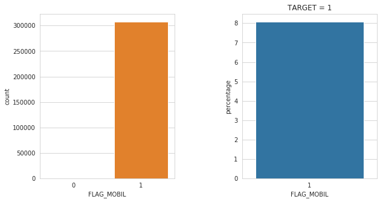

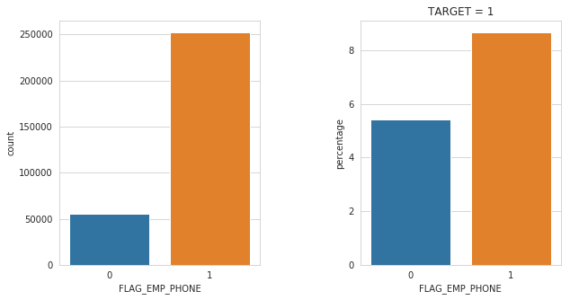

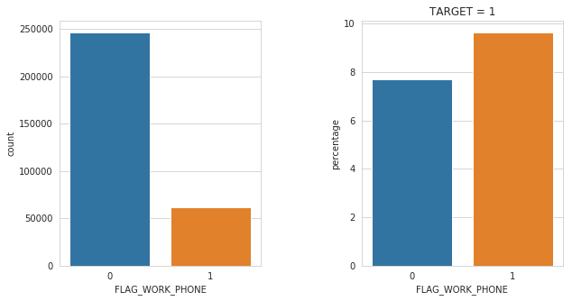

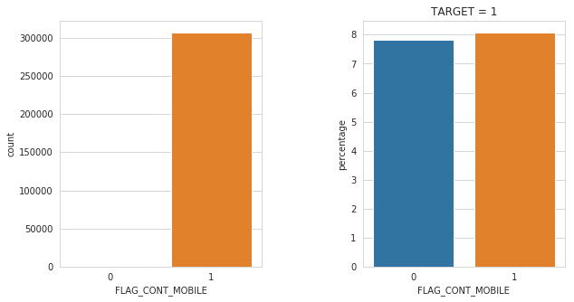

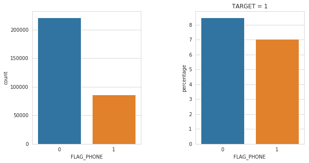

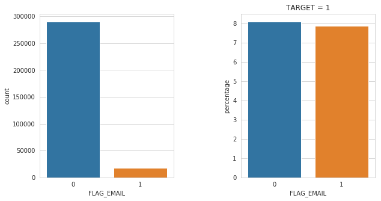

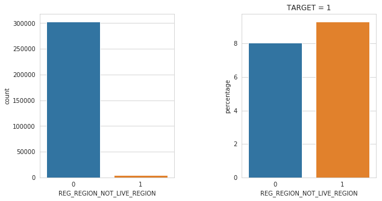

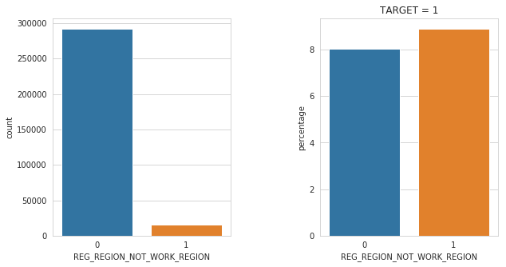

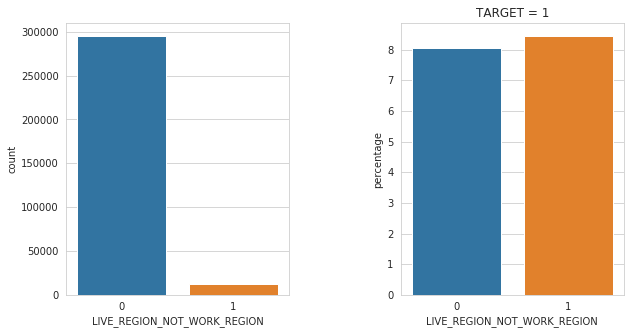

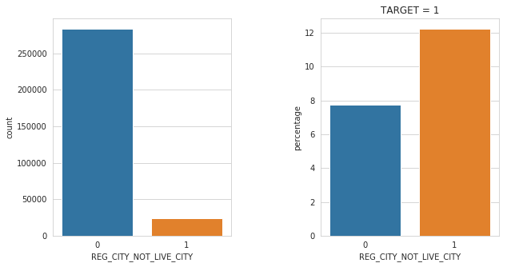

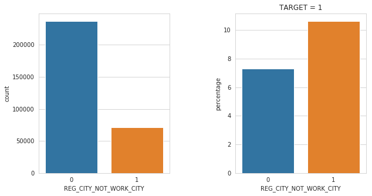

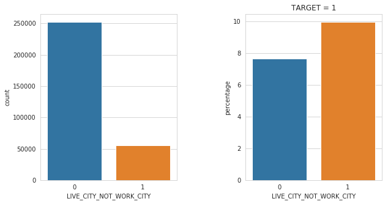

[20 more figures not shown]

```python
for feature in columns_binary:
    plot_binary_feature(df_application_train, feature, column_target)
```

### Категориальные признаки

Аналогичные графики построены для категориальных переменных.

На мой взгляд, среди категориальных признаков хорошими для модели могли бы оказаться: **CODE_GENDER, FLAG_OWN_CAR, NAME_INCOME_TYPE (Working), NAME_INCOME_TYPE (Pensioner), NAME_EDUCATION_TYPE, NAME_FAMILY_STATUS, NAME_HOUSING_TYPE, некоторые профессии, REGION_RATING_CLIENT, некоторые организации**. С полом я немного удивилась: как правило, мужчины зарабатывают больше, следовательно проблем с кредитом должно быть меньше. Но возможно женщины более ответственны, поэтому должниками становятся реже мужчин.

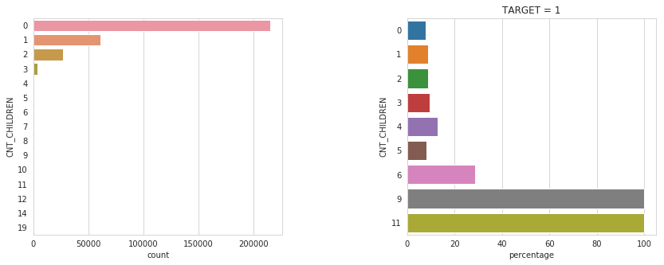

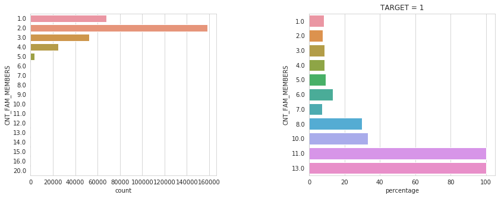

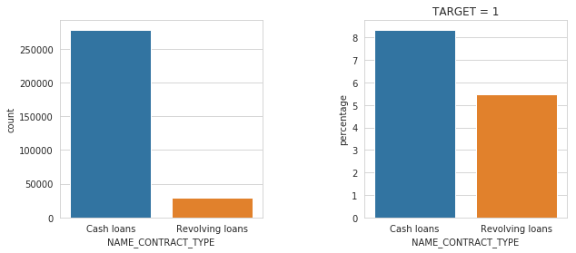

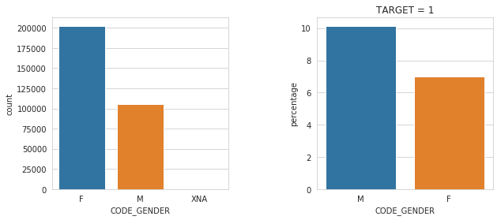

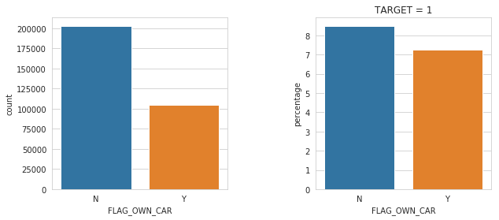

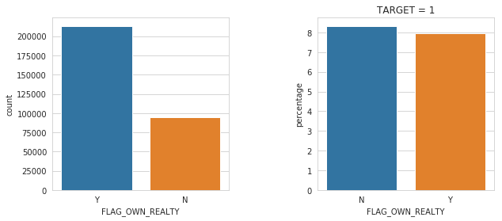

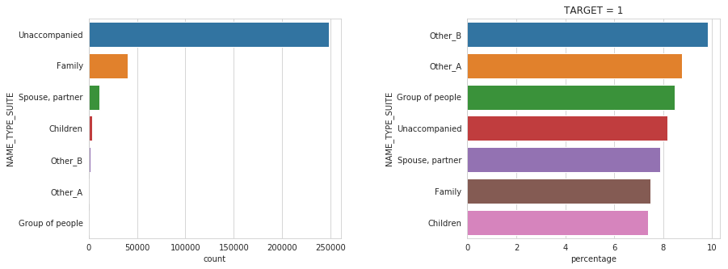

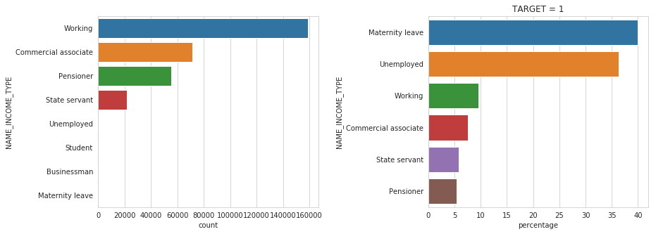

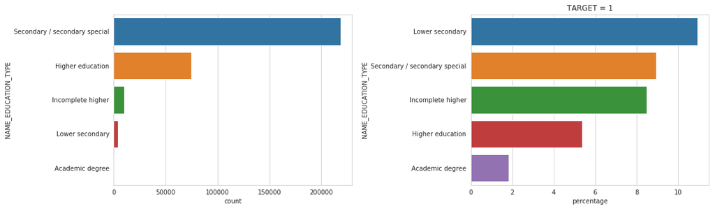

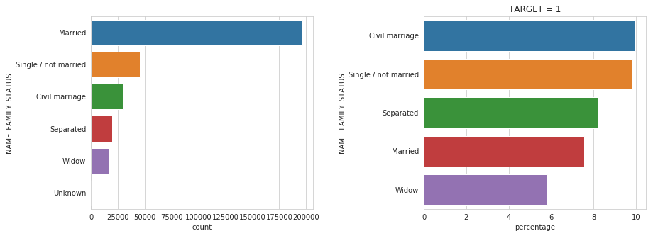

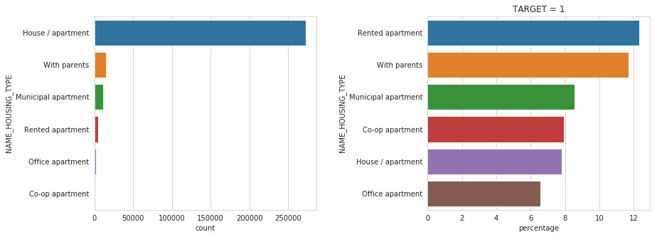

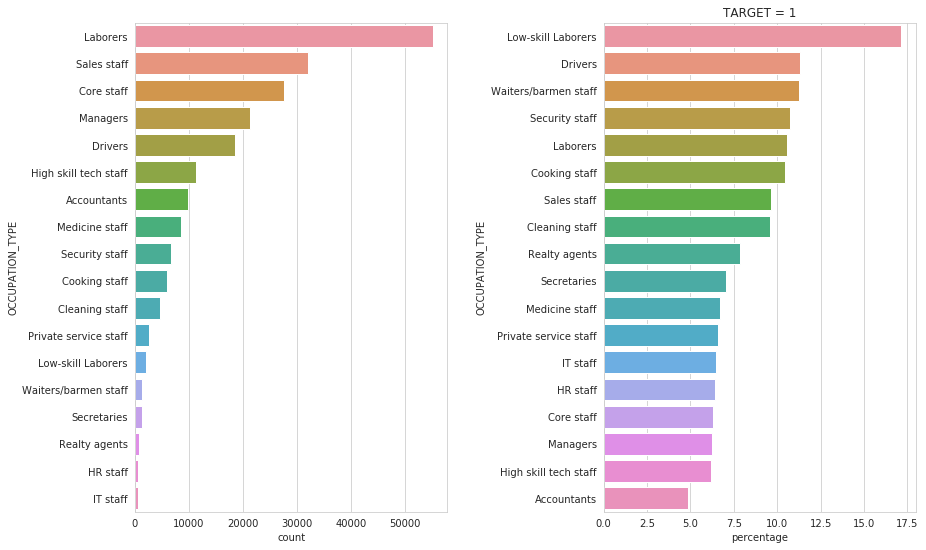

[9 more figures not shown]

```python
default_v = (10, 4)
default_h = (14, 5)

vocab = [('CNT_CHILDREN', 'h', default_h), ('CNT_FAM_MEMBERS', 'h', default_h),
        ('NAME_CONTRACT_TYPE', 'v', default_v), ('CODE_GENDER', 'v', default_v), \
       ('FLAG_OWN_CAR', 'v', default_v), ('FLAG_OWN_REALTY', 'v', default_v), \
       ('NAME_TYPE_SUITE', 'h', default_h), ('NAME_INCOME_TYPE', 'h', default_h), \
       ('NAME_EDUCATION_TYPE', 'h', (17, 5)), ('NAME_FAMILY_STATUS', 'h', default_h), \
       ('NAME_HOUSING_TYPE', 'h', default_h), ('OCCUPATION_TYPE', 'h', (14, 9)), \
       ('REGION_RATING_CLIENT', 'v', default_v), ('REGION_RATING_CLIENT_W_CITY', 'v', default_v), \
       ('WEEKDAY_APPR_PROCESS_START', 'h', default_h), ('HOUR_APPR_PROCESS_START', 'h', (14, 8)), \
       ('ORGANIZATION_TYPE', 'h', (14, 12)), ('FONDKAPREMONT_MODE', 'h', default_h), \
       ('HOUSETYPE_MODE', 'h', (14, 4)), ('WALLSMATERIAL_MODE', 'h', (14, 6)), \
       ('EMERGENCYSTATE_MODE', 'v', default_v)]

for (feature, orient, figsize) in vocab:
    plot_category_feature(df_application_train, feature, column_target, orient, figsize)
```

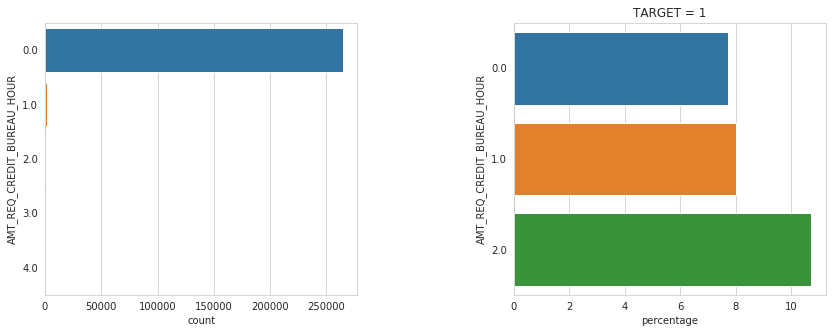

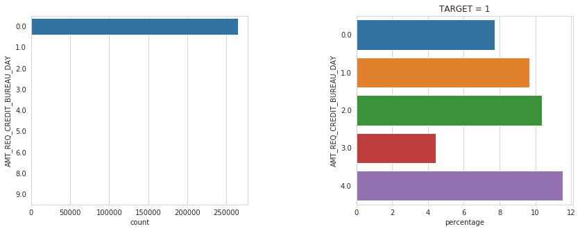

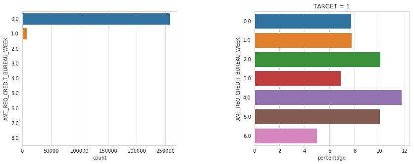

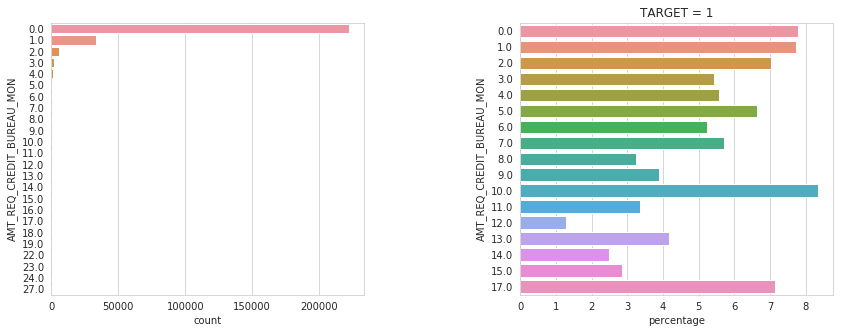

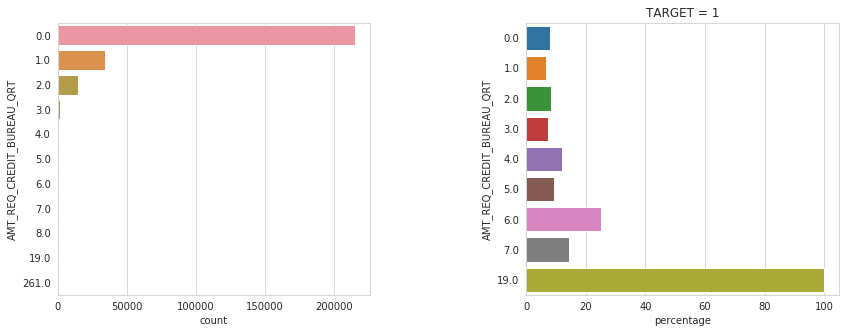

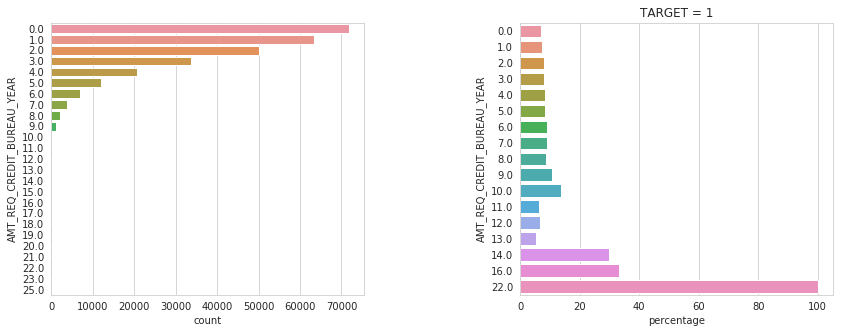

```python
default_v = (10, 4)
default_h = (14, 5)

vocab = [('AMT_REQ_CREDIT_BUREAU_HOUR', 'h', default_h), ('AMT_REQ_CREDIT_BUREAU_DAY', 'h', default_h), \
         ('AMT_REQ_CREDIT_BUREAU_WEEK', 'h', default_h), ('AMT_REQ_CREDIT_BUREAU_MON', 'h', default_h), \
         ('AMT_REQ_CREDIT_BUREAU_QRT', 'h', default_h), ('AMT_REQ_CREDIT_BUREAU_YEAR', 'h', default_h)]

for (feature, orient, figsize) in vocab:
    plot_category_feature(df_application_train, feature, column_target, orient, figsize)
```